# Regression analysis and model validation

## Regression model

For my regression model I pick the exam points as the target variable and attitude, strategic approach, and surface approach as explanatory variables.

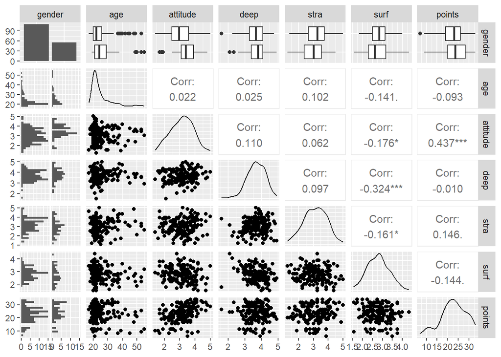

```r
library(GGally)
library(ggplot2)
# create an plot matrix with ggpairs()
ggpairs(students2014, lower = list(combo = wrap("facethist", bins = 20)))
```

```r
# create a regression model with multiple explanatory variables
my_model <- lm(points ~ attitude + stra + surf, data = students2014)

# print out a summary of the model
summary(my_model)
```

```
##
## Call:
## lm(formula = points ~ attitude + stra + surf, data = students2014)
##
## Residuals:
##      Min       1Q   Median       3Q      Max
## -17.1550  -3.4346   0.5156   3.6401  10.8952
##
## Coefficients:
##             Estimate Std. Error t value Pr(>|t|)
## (Intercept)  11.0171     3.6837   2.991  0.00322 **
## attitude      3.3952     0.5741   5.913 1.93e-08 ***
## stra          0.8531     0.5416   1.575  0.11716
## surf         -0.5861     0.8014  -0.731  0.46563
## ---
## Signif. codes:  0 '***' 0.001 '**' 0.01 '*' 0.05 '.' 0.1 ' ' 1
##
## Residual standard error: 5.296 on 162 degrees of freedom
## Multiple R-squared:  0.2074, Adjusted R-squared:  0.1927
## F-statistic: 14.13 on 3 and 162 DF,  p-value: 3.156e-08
```

My model is: points = 11,0171 + 3,3952 x attitude + 0,8531 x stra - 0,5861 x surf  
The model explains the test scores statistically significantly: F (3, 162) = 14,13, p=3,156e-08  
Multiple R-squared = 0,2074 so the three variables explains about 20 % of the exam points. However, Of the explanatory variables, only attitude has t-value greater than 2 (or less than -2), so that is actually the only variable in this model that is a good predictor of exam points.

## Model validation

The model is validated graphically:  
*Plot 1: Residuals vs fitted*  
This plot tells us if the residuals are homoscedastic. As the points in this scatter plot are distributed evenly, we can say that the residuals are homoscedastic.

*Plot 2: Normal Q-Q*  
This plot tells us wether the residuals are normally distributed. Since the dots on this graph form an approximately straight line going from corner to corner, we can conclude that the residuals are normally distributed.

*Plot 3: Residuals vs Leverage*  
This plot allows us to identify influential observations (or *outliers?*) in a regression model. Leverage refers to the extent to which the coefficients in the regression model would change if a particular observation was removed from the dataset. Observations with high leverage have a strong influence on the coefficients in the regression model. If we remove these observations, the coefficients of the model would change noticeably. If any point in this plot falls outside of Cook’s distance (the grey dashed lines) then it is considered to be an influential observation. There are no influental observations in this set.

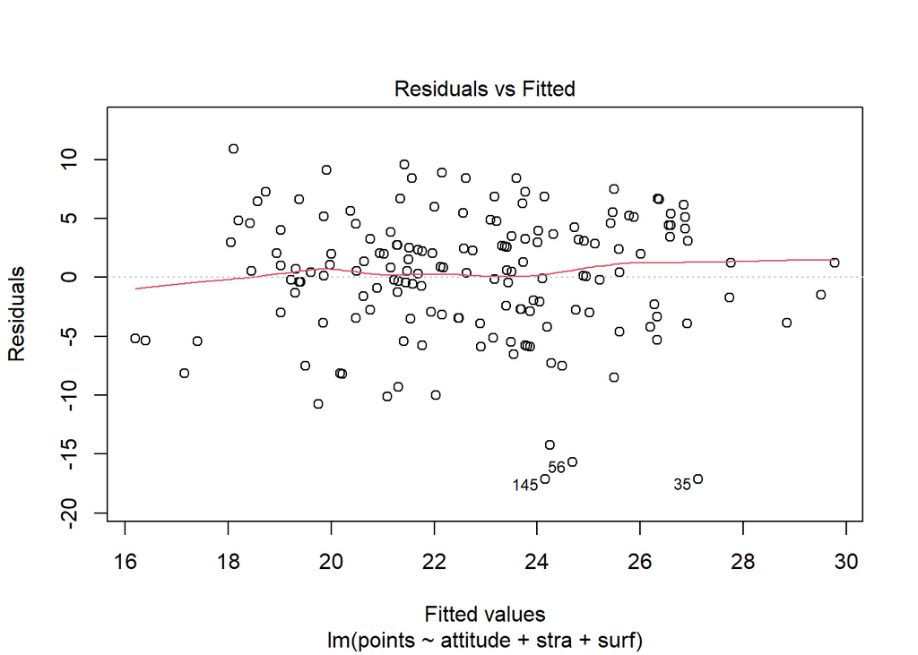

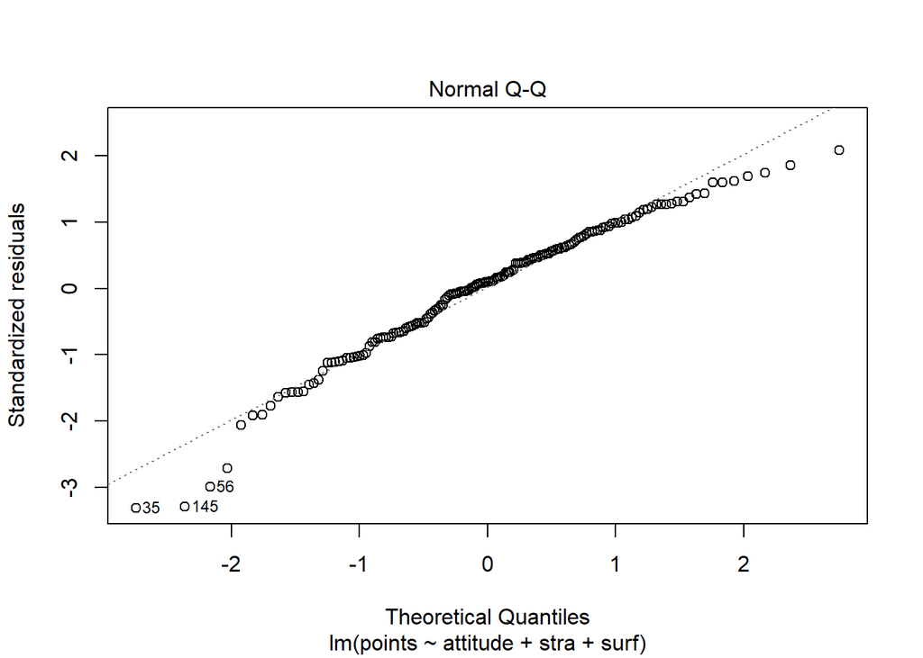

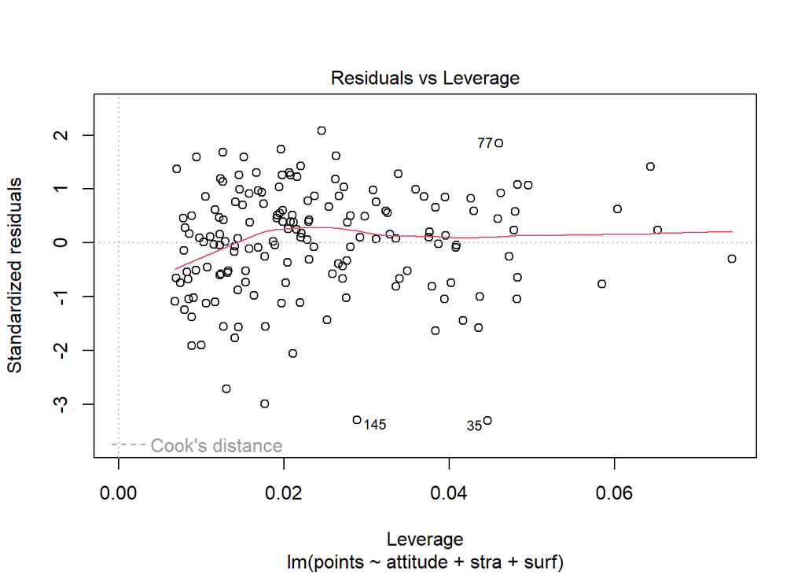

```r
# draw diagnostic plots using the plot() function. Plots 1 =  Residuals vs Fitted values, plot 2 = Normal QQ-plot and plot 5 = Residuals vs Leverage
plot(my_model, which = c(1,2,5))
```